# Lab 05 - Variabili Categoriche

Ilaria Prosdocimi

## Modelli con dati categoriali

Usiamo il dataset Prestige, che può essere estratto dal pacchetto `carData` (o leggiamo il file .csv):

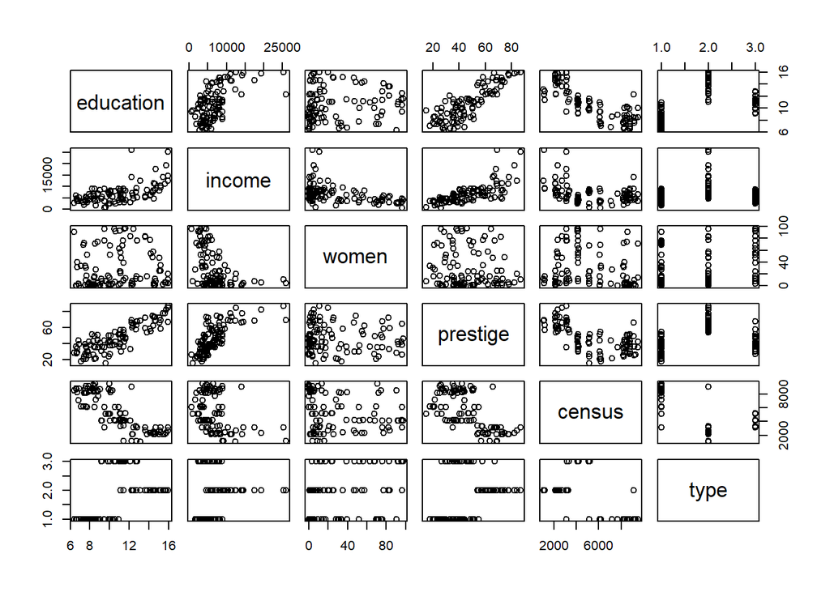

```
##                     education income women prestige census type
## gov.administrators      13.11  12351 11.16     68.8   1113 prof
## general.managers        12.26  25879  4.02     69.1   1130 prof
## accountants             12.77   9271 15.70     63.4   1171 prof
## purchasing.officers     11.42   8865  9.11     56.8   1175 prof
## chemists                14.62   8403 11.68     73.5   2111 prof
## physicists              15.64  11030  5.13     77.6   2113 prof
```

La variabile risposta è `Prestige`: si desidera individuare quali fattori influenzano il prestigio (percepito) di una professione.

Iniziamo con un modello in cui includiamo `income` ed `education`:

```r
fit1 <- lm(prestige ~ education+income, data = Prestige)
```

Andiamo a verificare se il modello è significativo e se rispetta le assunzioni usate per costruire il modello stesso:

```r
summary(fit1)
```

```
##
## Call:
## lm(formula = prestige ~ education + income, data = Prestige)
##
## Residuals:
##      Min       1Q   Median       3Q      Max
## -19.4040  -5.3308   0.0154   4.9803  17.6889
##
## Coefficients:
##               Estimate Std. Error t value Pr(>|t|)
## (Intercept) -6.8477787  3.2189771  -2.127   0.0359 *
## education    4.1374444  0.3489120  11.858  < 2e-16 ***
## income       0.0013612  0.0002242   6.071 2.36e-08 ***
## ---
## Signif. codes:  0 '***' 0.001 '**' 0.01 '*' 0.05 '.' 0.1 ' ' 1
##
## Residual standard error: 7.81 on 99 degrees of freedom
## Multiple R-squared:  0.798,  Adjusted R-squared:  0.7939
## F-statistic: 195.6 on 2 and 99 DF,  p-value: < 2.2e-16
```

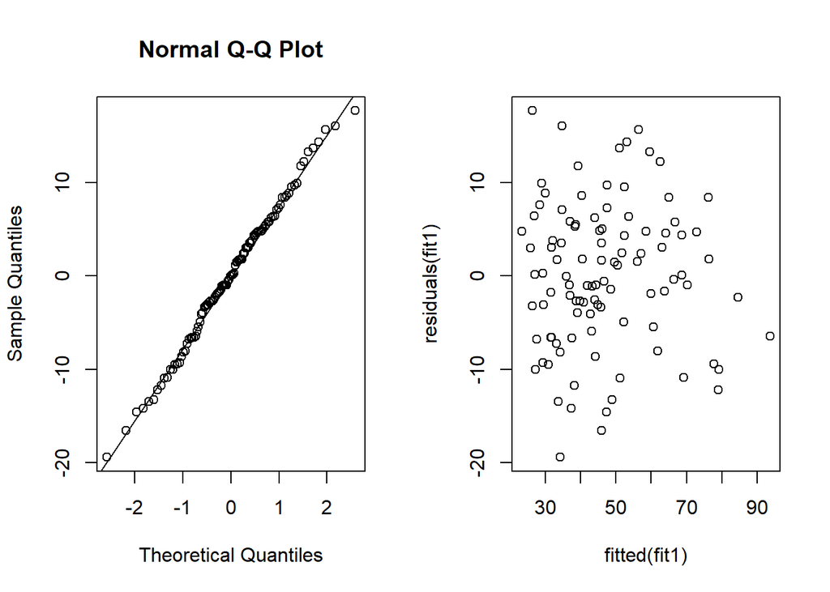

```r
# par(mfrow=c(2,2)); plot(fit1)
par(mfrow=c(1,2))
qqnorm(residuals(fit1)); qqline(residuals(fit1))
plot(fitted(fit1), residuals(fit1))
```

Nulla di particolarmente problematico nei residui: nessun segno evidente di eteroschedasticità o di non-normalità. Controlliamo poi se ci sono alcune delle altre variabili incluse nel dataset che possono aiutare a catturare variabilità aggiuntiva. Per questa indagine facciamo degli scatterplots dei potenziali predittori e i residui del modello:

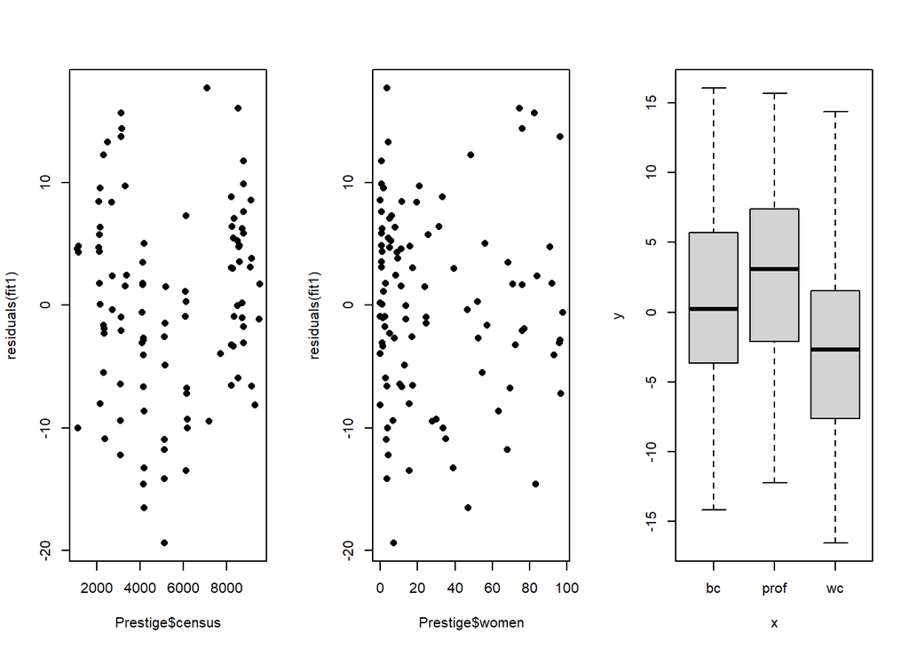

```r
par(mfrow=c(1,3),pch=16)
plot(Prestige$census, residuals(fit1))
plot(Prestige$women, residuals(fit1))
plot(Prestige$type, residuals(fit1))
```

`women` non sembra associata ai residui, ma sia `census` che `type` sembrano mostrare una qualche relazione, forse quadratica nel caso di `census`.

Proviamo ad aggiungerle al modello:

```r
fit_wthcensus <- lm(prestige ~ education+income+census, data = Prestige)
summary(fit_wthcensus)
```

```
##
## Call:
## lm(formula = prestige ~ education + income + census, data = Prestige)
##
## Residuals:
##      Min       1Q   Median       3Q      Max
## -19.0412  -5.2392  -0.0678   5.1002  18.5172
##
## Coefficients:
##               Estimate Std. Error t value Pr(>|t|)
## (Intercept) -1.507e+01  8.266e+00  -1.824   0.0713 .
## education    4.653e+00  5.907e-01   7.876 4.66e-12 ***
## income       1.300e-03  2.312e-04   5.622 1.78e-07 ***
## census       5.762e-04  5.334e-04   1.080   0.2827
## ---
## Signif. codes:  0 '***' 0.001 '**' 0.01 '*' 0.05 '.' 0.1 ' ' 1
##
## Residual standard error: 7.804 on 98 degrees of freedom
## Multiple R-squared:  0.8004, Adjusted R-squared:  0.7943
## F-statistic:   131 on 3 and 98 DF,  p-value: < 2.2e-16
```

```r
fit_wthtype <- lm(prestige ~ education+income+type, data = Prestige)
summary(fit_wthtype)
```

```
##
## Call:
## lm(formula = prestige ~ education + income + type, data = Prestige)
##
## Residuals:
##      Min       1Q   Median       3Q      Max
## -14.9529  -4.4486   0.1678   5.0566  18.6320
##
## Coefficients:
##               Estimate Std. Error t value Pr(>|t|)
## (Intercept) -0.6229292  5.2275255  -0.119    0.905
## education    3.6731661  0.6405016   5.735 1.21e-07 ***
## income       0.0010132  0.0002209   4.586 1.40e-05 ***
## typeprof     6.0389707  3.8668551   1.562    0.122
## typewc      -2.7372307  2.5139324  -1.089    0.279
## ---
## Signif. codes:  0 '***' 0.001 '**' 0.01 '*' 0.05 '.' 0.1 ' ' 1
##
## Residual standard error: 7.095 on 93 degrees of freedom
##   (4 osservazioni eliminate a causa di valori mancanti)
## Multiple R-squared:  0.8349, Adjusted R-squared:  0.8278
## F-statistic: 117.5 on 4 and 93 DF,  p-value: < 2.2e-16
```

Nessuna delle due variabili sembra essere significativa se presa singolarmente. Possiamo anche confrontare i diversi modelli stimati usando AIC:

```r
AIC(fit1); AIC(fit_wthcensus); AIC(fit_wthtype)
```

```
## [1] 713.7251
```

```
## [1] 714.5177
```

```
## [1] 669.0151
```

o più semplicemente

```r
AIC(fit1, fit_wthcensus, fit_wthtype)
```

```
## Warning in AIC.default(fit1, fit_wthcensus, fit_wthtype): i modelli non sono
## stati stimati per il medesimo numero di osservazioni
```

```
##               df      AIC
## fit1           4 713.7251
## fit_wthcensus  5 714.5177
## fit_wthtype    6 669.0151
```

Notiamo che R stampa un warning. Nel `summary` di `fit_wthtype` in effetti notiamo che quando usiamo la variabile `type` cambiano il numero di gradi di libertà a disposizione del modello: questo perché la variabile `type` ha dei valori mancanti ed R elimina le osservazioni che contengono dati mancanti quando stima il modello:

```r
Prestige[is.na(Prestige$type),]
```

```
##             education income women prestige census type
## athletes        11.44   8206  8.13     54.1   3373 <NA>
## newsboys         9.62    918  7.00     14.8   5143 <NA>
## babysitters      9.46    611 96.53     25.9   6147 <NA>
## farmers          6.84   3643  3.60     44.1   7112 <NA>
```

```r
dim(fit_wthcensus$model)
```

```
## [1] 102   4
```

```r
dim(fit_wthtype$model)
```

```
## [1] 98  4
```

Per poter confrontare i modelli dobbiamo essere sicuri che tutti i modelli siano stimati usando lo stesso dataset:

```r
# specify a smaller dataset
sfit1 <- lm(prestige ~ education+income, data = Prestige[!is.na(Prestige$type),])
# use the subset option in lm
sfit_wthcensus <- lm(prestige ~ education+income+census, data = Prestige, subset = !is.na(Prestige$type))
dim(sfit1$model); dim(sfit_wthcensus$model)
```

```
## [1] 98  3
```

```
## [1] 98  4
```

```r
# ok
```

Dato che `sfit_wthcensus` e `sfit_wthtype` non sono annidati facciamo un confronto basato solo su AIC

```r
AIC(sfit1, sfit_wthcensus, fit_wthtype)
```

```
##                df      AIC
## sfit1           4 676.6695
## sfit_wthcensus  5 676.8536
## fit_wthtype     6 669.0151
```

`fit_wthtype` ha una performance migliore, e sebbene i coefficienti per i due singoli livelli non siano significativi il modello in cui viene inclusa la variabile risulta significativamente migliore del modello senza la variabile in un test anova:

```r
anova(sfit1,fit_wthtype)
```

```
## Analysis of Variance Table
##
## Model 1: prestige ~ education + income
## Model 2: prestige ~ education + income + type
##   Res.Df    RSS Df Sum of Sq      F   Pr(>F)
## 1     95 5272.4
## 2     93 4681.3  2    591.16 5.8721 0.003966 **
## ---
## Signif. codes:  0 '***' 0.001 '**' 0.01 '*' 0.05 '.' 0.1 ' ' 1
```

Possiamo anche notare che `type` e `census` sono associati tra loro e includere entrambe le variabili potrebbe non portare a miglioramenti in termini di bontà di adattamento:

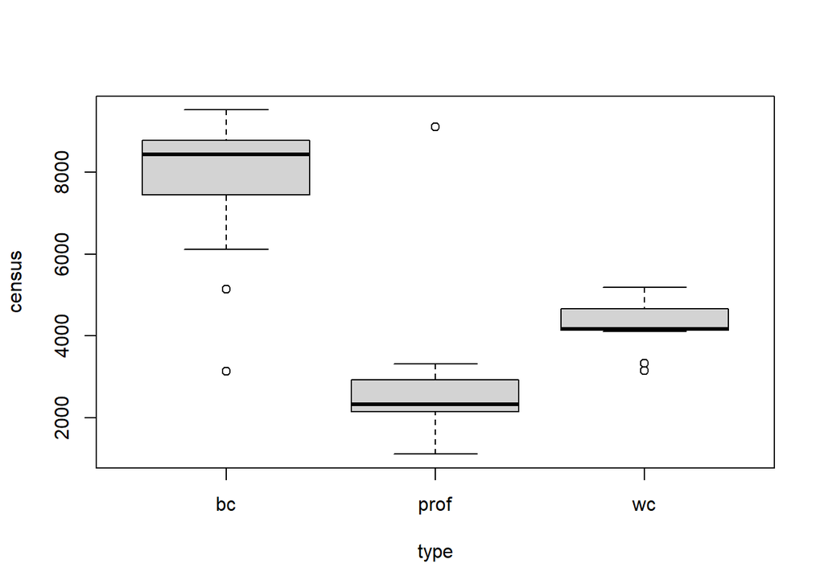

```r
plot(census~type,data=Prestige)
```

Infatti includere `type` elimina gran parte della forma residua di relazione tra `census` e i residui:

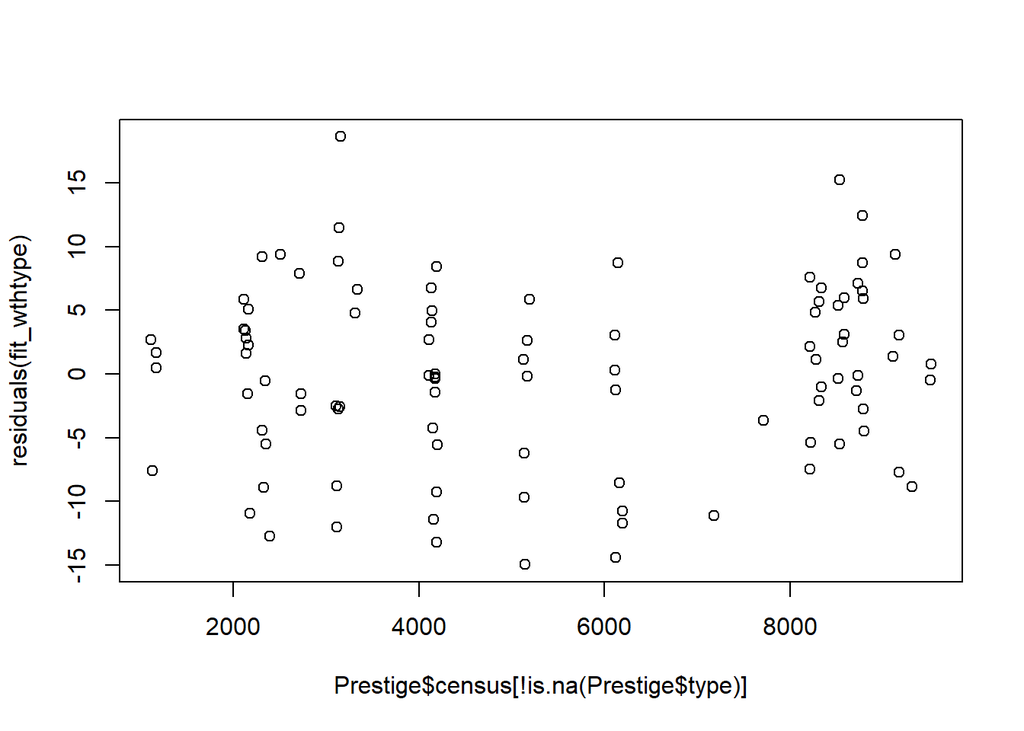

```r
plot(Prestige$census[!is.na(Prestige$type)],
     residuals(fit_wthtype))
```

Dato che il codice del censo non è veramente una variabile numerica che esprime una misura ma è una categorizzazione fatta dall’istituto di statistica ha più senso mantenere la variabile categoriale che descrive una vera caratteristica del dato (sebbene anche `type` sia un’informazione non misurabile empiricamente ma frutto di una valutazione fatta da persone).

Andiamo adesso a capire che modello è `fit_wthtype` esattamente e come R ha inserito nel modello una variale esplicativa che noi vediamo stampata come stringa nel dataset:

```r
## rewrite the dataset to only include complete information
Prestige <- Prestige[!is.na(Prestige$type),]
# what is type
class(Prestige$type)
```

```
## [1] "factor"
```

```r
table(Prestige$type)
```

```
##
##   bc prof   wc
##   44   31   23
```

```r
fit_wthtype$coefficients
```

```
##  (Intercept)    education       income     typeprof       typewc
## -0.622929165  3.673166052  0.001013193  6.038970651 -2.737230718
```

```r
cmod <- signif(fit_wthtype$coefficients,2)
```

I coefficienti legati ad `education` ed `income` sono positivi: lavori in cui si guadagna di più o per cui si è studiato più a lungo tendono ad essere più prestigiosi. La variabile `type` può avere tre valori: quando la aggiungiamo al modello aggiungiamo di fatto due coefficienti che descrivono la differenza del valore dell’intercetta per due dei tre gruppi rispetto ad un primo gruppo che è il gruppo di base. Di fatto vengono stimati tre iper-piani, uno per ogni gruppo con tre intercette diverse:

$$\text{if type = bc the model is}:
\hat{y}_i = -0.62 + 3.7* \text{education}_i + 0.001*
\text{income}_i$$
$$\text{if type =
prof the model is}: \hat{y}_i = (-0.62 + 6) + 3.7* \text{education}_i +
0.001* \text{income}_i$$
$$\text{if
type = wc the model is}: \hat{y}_i = (-0.62 + -2.7) + 3.7*
\text{education}_i + 0.001* \text{income}_i$$

Il livello `bc` della variabile `type` è il livello di riferimento, le stime per i lavori negli altri tipi di lavoro sono derivate rispetto al livello `bc`. Perché `bc`? R ordina i livelli in ordine alfabetico e prende il primo livello come modello di riferimento. R poi crea due variabili dicotomiche per i livelli che non sono quello di riferimento

```r
head(model.matrix(fit_wthtype))
```

```
##                     (Intercept) education income typeprof typewc
## gov.administrators            1     13.11  12351        1      0
## general.managers              1     12.26  25879        1      0
## accountants                   1     12.77   9271        1      0
## purchasing.officers           1     11.42   8865        1      0
## chemists                      1     14.62   8403        1      0
## physicists                    1     15.64  11030        1      0
```

```r
colSums(model.matrix(fit_wthtype))[4:5]
```

```
## typeprof   typewc
##       31       23
```

Diamo un occhio ai dati originali e i valori stimati dal modello in cui permettiamo di avere tre intercette diverse per ogni gruppo:

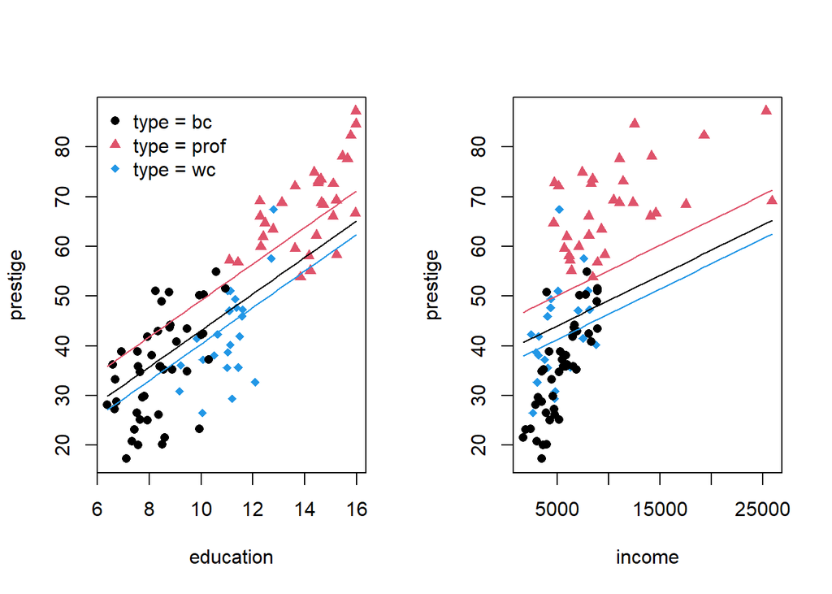

```r
par(mfrow=c(1,2))
plot(prestige~education, data=Prestige[!is.na(Prestige$type),],
     pch=16+ifelse(Prestige$type == "prof",1,0)+ifelse(Prestige$type == "wc",2,0),
     col=1+ifelse(Prestige$type == "prof",1,0)+ifelse(Prestige$type == "wc",3,0))
#### add the three lines evaluated at mean income
nd <- data.frame(education = rep(seq(min(Prestige$education),max(Prestige$education),
                                     length.out=40), times=3),
                 income = rep(mean(Prestige$income), 40*3),
                 type = rep(levels(Prestige$type), each=40))
lines(nd$education[nd$type == "bc"], predict(fit_wthtype,nd[nd$type == "bc",]))
lines(nd$education[nd$type == "prof"], predict(fit_wthtype,nd[nd$type == "prof",]),col=2)
lines(nd$education[nd$type == "wc"], predict(fit_wthtype,nd[nd$type == "wc",]),col=4)
legend("topleft", col = c(1,2,4), pch = c(16,17,18), bty = "n",
       legend = c("type = bc", "type = prof","type = wc"))
plot(prestige~income, data=Prestige[!is.na(Prestige$type),],
     pch=16+ifelse(Prestige$type == "prof",1,0)+ifelse(Prestige$type == "wc",2,0),
     col=1+ifelse(Prestige$type == "prof",1,0)+ifelse(Prestige$type == "wc",3,0))
#### add the three lines evaluated at mean income
nd <- data.frame(education = rep(mean(Prestige$education), 40*3),
                 income = rep(seq(min(Prestige$income),max(Prestige$income),
                                     length.out=40), times=3),
                 type = rep(levels(Prestige$type), each=40))
lines(nd$income[nd$type == "bc"], predict(fit_wthtype,nd[nd$type == "bc",]))
lines(nd$income[nd$type == "prof"], predict(fit_wthtype,nd[nd$type == "prof",]),col=2)
lines(nd$income[nd$type == "wc"], predict(fit_wthtype,nd[nd$type == "wc",]),col=4)
```

Si nota che i diversi gruppi hanno effettivamente livelli medi diversi di `prestige` e che la variabile `type` interagisce con `education` e `income`. Come possiamo inserire questa interazione con gli altri predittori nel modello? Possiamo stimare un modello in cui oltre a ad avere tre diverse intercette possiamo avere dei coefficienti angolari diversi per ogni gruppo, cioè permettere che la relazione tra i predittori e la variabile risposta sia diversa per ogni gruppo. Iniziamo da un modello piuttosto complesso in cui permettiamo a `type` di interagire con `income` o `education` e permettiamo quindi che i coefficienti angolari per entrambi i predittori numerici siano diversi per ognuno dei tre gruppi:

```r
fit_intrall <- lm(prestige~education+income+type+education:type+income:type, data = Prestige)
# summary(fit_intrall)
#### guardiamo la matrice di disegno
head(model.matrix(fit_intrall))
```

```
##                     (Intercept) education income typeprof typewc
## gov.administrators            1     13.11  12351        1      0
## general.managers              1     12.26  25879        1      0
## accountants                   1     12.77   9271        1      0
## purchasing.officers           1     11.42   8865        1      0
## chemists                      1     14.62   8403        1      0
## physicists                    1     15.64  11030        1      0
##                     education:typeprof education:typewc income:typeprof
## gov.administrators               13.11                0           12351
## general.managers                 12.26                0           25879
## accountants                      12.77                0            9271
## purchasing.officers              11.42                0            8865
## chemists                         14.62                0            8403
## physicists                       15.64                0           11030
##                     income:typewc
## gov.administrators              0
## general.managers                0
## accountants                     0
## purchasing.officers             0
## chemists                        0
## physicists                      0
```

```r
colSums(model.matrix(fit_intrall))
```

```
##        (Intercept)          education             income           typeprof
##              98.00            1057.92          680008.00              31.00
##             typewc education:typeprof   education:typewc    income:typeprof
##              23.00             436.61             253.50          327343.00
##      income:typewc
##          116203.00
```

```r
sum(Prestige$income[Prestige$type == "wc"], na.rm=TRUE)
```

```
## [1] 116203
```

Il modello stimato è il seguente:

$$\begin{equation}
\begin{split}
Y_i = \beta_0 + \beta_{ed} * \text{education}_i + \beta_{inc} *
\text{income}_i + \beta_{type:prod} \text{type:prof} + \beta_{type:wc}
\text{type:wc} +
\beta_{ed,type:prof} * \text{education}_i * \text{type:prof} + \\
\beta_{ed,type:wc} * \text{education}_i * \text{type:wc} +
\beta_{inc,type:prof} * \text{income}_i * \text{type:prof} +
\beta_{inc,type:wc} * \text{income}_i * \text{type:wc} +
\epsilon_i
\end{split}
\end{equation}$$

dove $\varepsilon_i$ è l’errore $\varepsilon_i \sim N(0, \sigma^2)$ (NB: c’è un solo parametro $\sigma$ che descrive la variabilità dell’errore per tutti i gruppi).

Per ogni gruppo quindi viene stimato un modello diverso:
$$\text{if type = bc}:
Y_i = \beta_0 + \beta_{ed} * \text{education}_i + \beta_{inc} *
\text{income}_i + \epsilon_i$$

$$\text{if type = prof}:
Y_i = \beta_0 + \beta_{ed} * \text{education}_i + \beta_{inc} *
\text{income}_i +
\beta_{type:prof} \text{type:prof} + \\
\beta_{ed,type:prof} * \text{education}_i * \text{type:prof} +
\beta_{inc,type:prof} * \text{income}_i * \text{type:prof} +
\epsilon_i$$

$$\text{if type = wc}:
Y_i = \beta_0 + \beta_{ed} * \text{education}_i + \beta_{inc} *
\text{income}_i +
\beta_{type:wc} \text{type:wc} + \\
\beta_{ed,type:wc} * \text{education}_i * \text{type:wc} +
\beta_{inc,type:wc} * \text{income}_i * \text{type:wc} +
\epsilon_i$$

Vediamo un riassunto della stima ottenuta:

```r
summary(fit_intrall)
```

```
##
## Call:
## lm(formula = prestige ~ education + income + type + education:type +
##     income:type, data = Prestige)
##
## Residuals:
##     Min      1Q  Median      3Q     Max
## -13.462  -4.225   1.346   3.826  19.631
##
## Coefficients:
##                      Estimate Std. Error t value Pr(>|t|)
## (Intercept)         2.276e+00  7.057e+00   0.323   0.7478
## education           1.713e+00  9.572e-01   1.790   0.0769 .
## income              3.522e-03  5.563e-04   6.332 9.62e-09 ***
## typeprof            1.535e+01  1.372e+01   1.119   0.2660
## typewc             -3.354e+01  1.765e+01  -1.900   0.0607 .
## education:typeprof  1.388e+00  1.289e+00   1.077   0.2844
## education:typewc    4.291e+00  1.757e+00   2.442   0.0166 *
## income:typeprof    -2.903e-03  5.989e-04  -4.847 5.28e-06 ***
## income:typewc      -2.072e-03  8.940e-04  -2.318   0.0228 *
## ---
## Signif. codes:  0 '***' 0.001 '**' 0.01 '*' 0.05 '.' 0.1 ' ' 1
##
## Residual standard error: 6.318 on 89 degrees of freedom
## Multiple R-squared:  0.8747, Adjusted R-squared:  0.8634
## F-statistic: 77.64 on 8 and 89 DF,  p-value: < 2.2e-16
```

Vediamo che molti parametri del modello non risultano significativi. La variabilità della stima è aumentata, si confrontino per esempio gli intervalli di confidenza del parametro associato ad `education` nel modello in cui `type` non interagisce con gli altri predittori (`confint(fit_wthtype, parm ="education")`) e nel modello con l’interazione (`confint(fit_intrall, parm ="education")`): stiamo stimando molti parametri con un numero non poi così grande di osservazioni e rischiamo di sovra-parametrizzare il nostro modello. Tuttavia spieghiamo buona parte della variabilità della variabile risposta e vediamo che il test anova indica un miglioramento significativo della bontà di adattamento quando confrontiamo il modello con le interazioni contro il modello senza interazioni:

```r
anova(fit_wthtype, fit_intrall)
```

```
## Analysis of Variance Table
##
## Model 1: prestige ~ education + income + type
## Model 2: prestige ~ education + income + type + education:type + income:type
##   Res.Df    RSS Df Sum of Sq      F    Pr(>F)
## 1     93 4681.3
## 2     89 3552.9  4    1128.4 7.0668 5.479e-05 ***
## ---
## Signif. codes:  0 '***' 0.001 '**' 0.01 '*' 0.05 '.' 0.1 ' ' 1
```

```r
#  anche AIC indica che fit_intrall è da preferire
AIC(fit_wthtype, fit_intrall)
```

```
##             df      AIC
## fit_wthtype  6 669.0151
## fit_intrall 10 649.9850
```

Guardiamo i valori stimati:

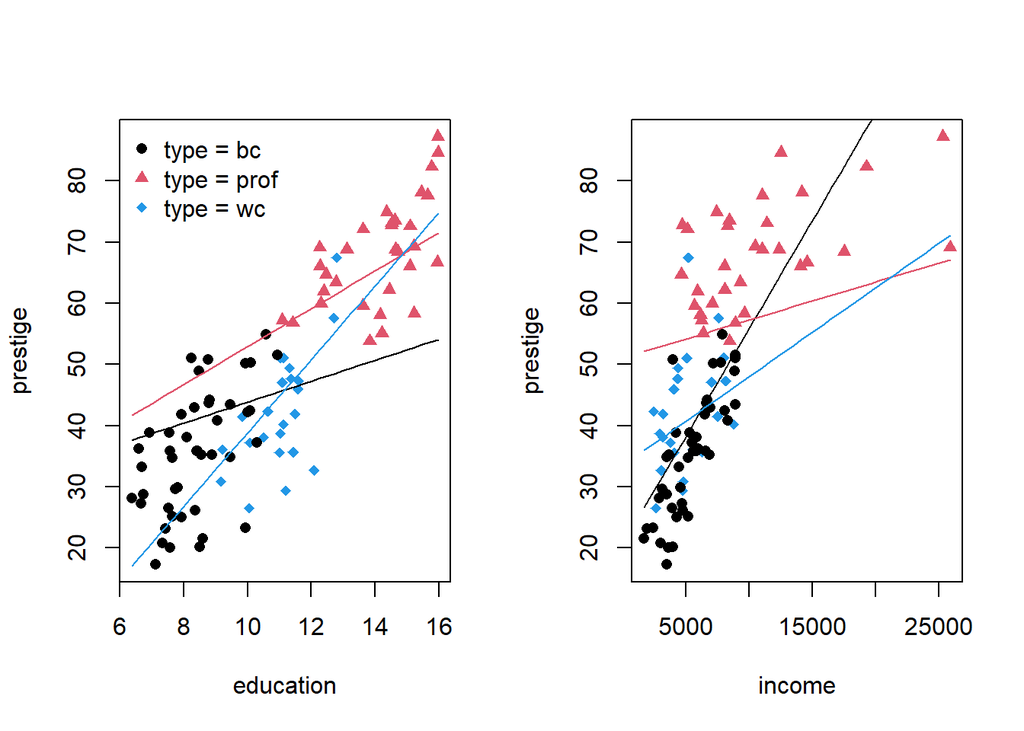

```r
par(mfrow=c(1,2))
plot(prestige~education, data=Prestige[!is.na(Prestige$type),],
     pch=16+ifelse(Prestige$type == "prof",1,0)+ifelse(Prestige$type == "wc",2,0),
     col=1+ifelse(Prestige$type == "prof",1,0)+ifelse(Prestige$type == "wc",3,0))
#### add the three lines evaluated at mean income
nd <- data.frame(education = rep(seq(min(Prestige$education),max(Prestige$education),
                                     length.out=40), times=3),
                 income = rep(mean(Prestige$income), 40*3),
                 type = rep(levels(Prestige$type), each=40))
lines(nd$education[nd$type == "bc"], predict(fit_intrall,nd[nd$type == "bc",]))
lines(nd$education[nd$type == "prof"], predict(fit_intrall,nd[nd$type == "prof",]),col=2)
lines(nd$education[nd$type == "wc"], predict(fit_intrall,nd[nd$type == "wc",]),col=4)
legend("topleft", col = c(1,2,4), pch = c(16,17,18), bty = "n",
       legend = c("type = bc", "type = prof","type = wc"))
plot(prestige~income, data=Prestige[!is.na(Prestige$type),],
     pch=16+ifelse(Prestige$type == "prof",1,0)+ifelse(Prestige$type == "wc",2,0),
     col=1+ifelse(Prestige$type == "prof",1,0)+ifelse(Prestige$type == "wc",3,0))
#### add the three lines evaluated at mean income
nd <- data.frame(education = rep(mean(Prestige$education), 40*3),
                 income = rep(seq(min(Prestige$income),max(Prestige$income),
                                     length.out=40), times=3),
                 type = rep(levels(Prestige$type), each=40))
lines(nd$income[nd$type == "bc"], predict(fit_intrall,nd[nd$type == "bc",]))
lines(nd$income[nd$type == "prof"], predict(fit_intrall,nd[nd$type == "prof",]),col=2)
lines(nd$income[nd$type == "wc"], predict(fit_intrall,nd[nd$type == "wc",]),col=4)
```

Tuttavia potrebbe essere un modello troppo variabile da usare in pratica, proviamo a cercare una via di mezzo in cui solo uno dei predittori continui interagisce con la variabile categoriale.

```r
fit_intred <- lm(prestige~education+income+type+education:type, data = Prestige)
#summary(fit_intred)
fit_intrinc <- lm(prestige~education+income+type+income:type, data = Prestige)
#summary(fit_intrinc)
```

Questi due modelli sono annidati in `fit_intrall` quindi possiamo verificare tramite test anova se escludere l’interazione con uno dei predittori continui cambia in maniera significativa la bontà di adattamento del modello. Iniziamo con testare se possiamo eliminare l’interazione tra `education` e `type` ($H_0:$ i due parametri legati ai coefficienti angolari di `education` per i due gruppi non di riferimento sono pari a 0):

```r
anova(fit_intrinc, fit_intrall)
```

```
## Analysis of Variance Table
##
## Model 1: prestige ~ education + income + type + income:type
## Model 2: prestige ~ education + income + type + education:type + income:type
##   Res.Df    RSS Df Sum of Sq      F  Pr(>F)
## 1     91 3791.3
## 2     89 3552.9  2     238.4 2.9859 0.05557 .
## ---
## Signif. codes:  0 '***' 0.001 '**' 0.01 '*' 0.05 '.' 0.1 ' ' 1
```

Evidenza non fortissima contro $H_0$, al tipico livello di significatività del 5% non rifiuteremmo $H_0$: escludere l’interazione `education` non riduce di molto la bontà di adattamento del modello.

Testiamo anche se sia possibile eliminare l’interazione tra `income` e `type` :

```r
anova(fit_intred, fit_intrall)
```

```
## Analysis of Variance Table
##
## Model 1: prestige ~ education + income + type + education:type
## Model 2: prestige ~ education + income + type + education:type + income:type
##   Res.Df    RSS Df Sum of Sq      F    Pr(>F)
## 1     91 4504.6
## 2     89 3552.9  2    951.77 11.921 2.588e-05 ***
## ---
## Signif. codes:  0 '***' 0.001 '**' 0.01 '*' 0.05 '.' 0.1 ' ' 1
```

Evidenza piuttosto forte contro $H_0$: escludere questa interazione cambia di molto la capacità del modello di catturare la variabilità nei dati. Dovendo scegliere un modello in cui permettiamo l’interazione della variabile categorica solo con un predittore continuo sembra essere meglio permettere l’interazione con `income`. Infine possiamo testare se questo modello è significativamente diverso dal modello senza interazione.

```r
anova(fit_wthtype, fit_intrinc)
```

```
## Analysis of Variance Table
##
## Model 1: prestige ~ education + income + type
## Model 2: prestige ~ education + income + type + income:type
##   Res.Df    RSS Df Sum of Sq      F    Pr(>F)
## 1     93 4681.3
## 2     91 3791.3  2    890.02 10.681 6.809e-05 ***
## ---
## Signif. codes:  0 '***' 0.001 '**' 0.01 '*' 0.05 '.' 0.1 ' ' 1
```

C’è una differenza significativa tra i RSS dei due modelli: l’interazione è necessaria per catturare qualche caratteristica presente nei dati.

```r
summary(fit_intrinc)
```

```
##
## Call:
## lm(formula = prestige ~ education + income + type + income:type,
##     data = Prestige)
##
## Residuals:
##      Min       1Q   Median       3Q      Max
## -12.8720  -4.8321   0.8534   4.1425  19.6710
##
## Coefficients:
##                   Estimate Std. Error t value Pr(>|t|)
## (Intercept)     -6.7272633  4.9515480  -1.359   0.1776
## education        3.0396961  0.6003699   5.063 2.14e-06 ***
## income           0.0031344  0.0005215   6.010 3.79e-08 ***
## typeprof        25.1723873  5.4669586   4.604 1.34e-05 ***
## typewc           7.1375093  5.2898177   1.349   0.1806
## income:typeprof -0.0025102  0.0005530  -4.539 1.72e-05 ***
## income:typewc   -0.0014856  0.0008720  -1.704   0.0919 .
## ---
## Signif. codes:  0 '***' 0.001 '**' 0.01 '*' 0.05 '.' 0.1 ' ' 1
##
## Residual standard error: 6.455 on 91 degrees of freedom
## Multiple R-squared:  0.8663, Adjusted R-squared:  0.8574
## F-statistic: 98.23 on 6 and 91 DF,  p-value: < 2.2e-16
```

Possiamo anche usare AIC, BIC o $R^2_{adj}$ per confrontare i vari modelli:

```r
AIC(fit_wthtype, fit_intred, fit_intrinc, fit_intrall)
```

```
##             df      AIC
## fit_wthtype  6 669.0151
## fit_intred   8 669.2456
## fit_intrinc  8 652.3495
## fit_intrall 10 649.9850
```

```r
BIC(fit_wthtype, fit_intred, fit_intrinc, fit_intrall)
```

```
##             df      BIC
## fit_wthtype  6 684.5249
## fit_intred   8 689.9253
## fit_intrinc  8 673.0293
## fit_intrall 10 675.8346
```

```r
summary(fit_wthtype)$adj.r.square; summary(fit_intred)$adj.r.square
```

```
## [1] 0.8277545
```

```
## [1] 0.8306113
```

```r
summary(fit_intrinc)$adj.r.square; summary(fit_intrall)$adj.r.square
```

```
## [1] 0.8574365
```

```
## [1] 0.8633987
```

I criteri non concordano su quale sia il modello migliore, ma non sappiamo quale sia effettivamente il modello migliore dato che non conosciamo il *vero* processo che genera i dati. A seconda del criterio adottato sceglieremo un modello diverso come modello ottimale: l’importante è essere coerenti sulla metrica che si usa per confrontare i modelli.

Guardiamo i valori stimati dal modello `fit_intrinc`:

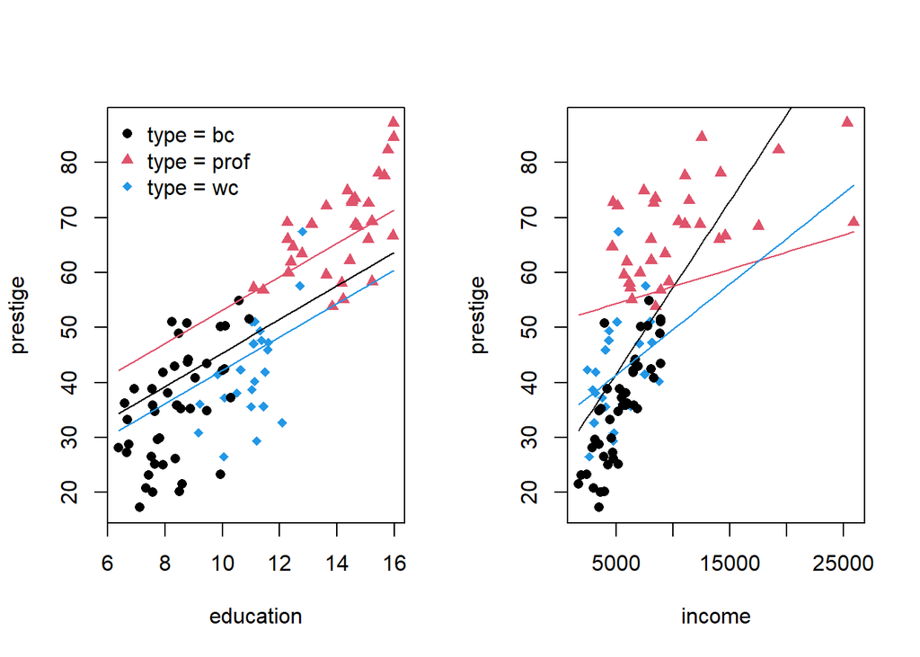

```r
par(mfrow=c(1,2))
plot(prestige~education, data=Prestige[!is.na(Prestige$type),],
     pch=16+ifelse(Prestige$type == "prof",1,0)+ifelse(Prestige$type == "wc",2,0),
     col=1+ifelse(Prestige$type == "prof",1,0)+ifelse(Prestige$type == "wc",3,0))
#### add the three lines evaluated at mean income
nd <- data.frame(education = rep(seq(min(Prestige$education),max(Prestige$education),
                                     length.out=40), times=3),
                 income = rep(mean(Prestige$income), 40*3),
                 type = rep(levels(Prestige$type), each=40))
lines(nd$education[nd$type == "bc"], predict(fit_intrinc,nd[nd$type == "bc",]))
lines(nd$education[nd$type == "prof"], predict(fit_intrinc,nd[nd$type == "prof",]),col=2)
lines(nd$education[nd$type == "wc"], predict(fit_intrinc,nd[nd$type == "wc",]),col=4)
legend("topleft", col = c(1,2,4), pch = c(16,17,18), bty = "n",
       legend = c("type = bc", "type = prof","type = wc"))
plot(prestige~income, data=Prestige[!is.na(Prestige$type),],
     pch=16+ifelse(Prestige$type == "prof",1,0)+ifelse(Prestige$type == "wc",2,0),
     col=1+ifelse(Prestige$type == "prof",1,0)+ifelse(Prestige$type == "wc",3,0))
#### add the three lines evaluated at mean income
nd <- data.frame(education = rep(mean(Prestige$education), 40*3),
                 income = rep(seq(min(Prestige$income),max(Prestige$income),
                                     length.out=40), times=3),
                 type = rep(levels(Prestige$type), each=40))
lines(nd$income[nd$type == "bc"], predict(fit_intrinc,nd[nd$type == "bc",]))
lines(nd$income[nd$type == "prof"], predict(fit_intrinc,nd[nd$type == "prof",]),col=2)
lines(nd$income[nd$type == "wc"], predict(fit_intrinc,nd[nd$type == "wc",]),col=4)
```

Per visualizzare ancora meglio la relazione che possiamo pensare di stimare per ogni gruppo possiamo valutare la funzione non per i valori medi globali di rispettivamente `income` ed `education` ma per i valori medi di ogni gruppo. Visualizziamo la cosa andando direttamente a “disegnare” le linee stimate (senza cioè usare `predict`):

```r
par(mfrow=c(1,2))
cvec <- fit_intrinc$coefficients # vector of coefs
#### add the three lines evaluated at mean income, BUT
### income is not the same across the three groups
### take group mean
(minvec <- tapply(Prestige$income, Prestige$type,mean))
```

```
##        bc      prof        wc
##  5374.136 10559.452  5052.304
```

```r
plot(prestige~education, data=Prestige[!is.na(Prestige$type),],
     pch=16+ifelse(Prestige$type == "prof",1,0)+ifelse(Prestige$type == "wc",2,0),
     col=1+ifelse(Prestige$type == "prof",1,0)+ifelse(Prestige$type == "wc",3,0))
abline(cvec[1]+cvec[3]*minvec[1],cvec[2])
abline(cvec[1]+cvec[3]*minvec[2]+cvec[4]+cvec[6]*minvec[2],cvec[2], col = 2)
abline(cvec[1]+cvec[3]*minvec[3]+cvec[5]+cvec[7]*minvec[2],cvec[2], col = 4)
### education is not equal across groups
(medvec <- tapply(Prestige$education, Prestige$type,mean))
```

```
##        bc      prof        wc
##  8.359318 14.084194 11.021739
```

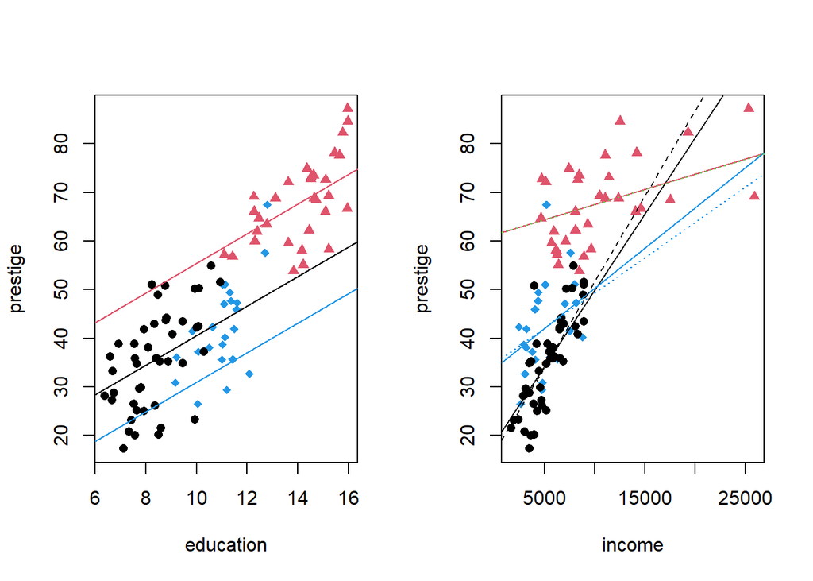

```r
plot(prestige~income, data=Prestige[!is.na(Prestige$type),],
     pch=16+ifelse(Prestige$type == "prof",1,0)+ifelse(Prestige$type == "wc",2,0),
     col=1+ifelse(Prestige$type == "prof",1,0)+ifelse(Prestige$type == "wc",3,0))
abline(cvec[1]+cvec[2]*medvec[1],cvec[3])
abline(cvec[1]+cvec[2]*medvec[2]+cvec[4],cvec[3]+cvec[6], col = 2)
abline(cvec[1]+cvec[2]*medvec[3]+cvec[5],cvec[3]+cvec[7], col = 4)

### what would the lines look like if we had fitted each group separately?
l1 <- lm(prestige ~ education + income, data = Prestige, subset = (type == "bc"))$coef
abline(l1[1]+l1[2]*medvec[1], l1[3], lty = 2)
l2 <- lm(prestige ~ education + income, data = Prestige, subset = (type == "prof"))$coef
abline(l2[1]+l2[2]*medvec[2], l2[3], lty = 3, col = 3)
l3 <- lm(prestige ~ education + income, data = Prestige, subset = (type == "wc"))$coef
abline(l3[1]+l3[2]*medvec[3], l3[3], lty = 3, col = 4)
```

```r
# not too far off....
```

*Nota bene: fin’ora abbiamo usato `type` come codificata nel dataset. Guardando i grafici e i livelli di significatività dei coefficienti si potrebbe sospettare che siano solo le professioni del gruppo `prof` ad avere una relazione diversa tra `education` e `prestige` e `income` e `prestige`, mentre le professioni in `"bc"` e `"wc"` si comportano in maniera simile. Possiamo creare una variabile dicotomica che differenzi solo i lavori `prof` da quelli `bc` e `wc` e fare una nuova analisi*

## Il livello di riferimento: usare i factors in R

R usa il livello `"bc"` come livello di riferimento perché è il primo livello in ordine alfabetico. Tutti i coefficienti stimati nel modello sono quindi relativi al livello `bc`. Possiamo cambiare il livello di riferimento in modo che i parametri del modello rappresentino la differenza di intercetta e coefficiente angolare rispetto ad livello che non sia `bc`, ma per esempio `prof` che funge quindi da livello di riferimento. Per fare questo in R dobbiamo usare l’argomento `levels` nella funzione `factor` per specificare i livelli della variabile:

```r
class(Prestige$type)
```

```
## [1] "factor"
```

```r
table(Prestige$type)
```

```
##
##   bc prof   wc
##   44   31   23
```

```r
levels(Prestige$type)
```

```
## [1] "bc"   "prof" "wc"
```

```r
Prestige$newtype <- factor(Prestige$type, levels = c("prof","wc","bc"))
table(Prestige$newtype)
```

```
##
## prof   wc   bc
##   31   23   44
```

```r
fit_newlevels <- lm(prestige ~ education + income + newtype, data = Prestige)
fit_newlevels$coefficients
```

```
##  (Intercept)    education       income    newtypewc    newtypebc
##  5.416041486  3.673166052  0.001013193 -8.776201369 -6.038970651
```

Vediamo che abbiamo dei coefficienti aggiuntivi stimati per i gruppi `wc` e `bc`. Tuttavia a livello numerico non cambia nulla e otteniamo le stesse stime:

```r
fit_newlevels$coefficients
```

```
##  (Intercept)    education       income    newtypewc    newtypebc
##  5.416041486  3.673166052  0.001013193 -8.776201369 -6.038970651
```

```r
fit_wthtype$coefficients
```

```
##  (Intercept)    education       income     typeprof       typewc
## -0.622929165  3.673166052  0.001013193  6.038970651 -2.737230718
```

```r
nd <- data.frame(education = rep(mean(Prestige$education),3),
                 income = rep(mean(Prestige$income),3),
                 type = c("bc","prof","wc"),
                 newtype = c("bc","prof","wc"))
predict(fit_wthtype, nd)
```

```
##        1        2        3
## 46.05968 52.09865 43.32244
```

```r
predict(fit_newlevels, nd)
```

```
##        1        2        3
## 46.05968 52.09865 43.32244
```

quello che cambia è la matrice di disegno usata da R per stimare il modello:

```r
head(model.matrix(fit_wthtype))
```

```
##                     (Intercept) education income typeprof typewc
## gov.administrators            1     13.11  12351        1      0
## general.managers              1     12.26  25879        1      0
## accountants                   1     12.77   9271        1      0
## purchasing.officers           1     11.42   8865        1      0
## chemists                      1     14.62   8403        1      0
## physicists                    1     15.64  11030        1      0
```

```r
head(model.matrix(fit_newlevels))
```

```
##                     (Intercept) education income newtypewc newtypebc
## gov.administrators            1     13.11  12351         0         0
## general.managers              1     12.26  25879         0         0
## accountants                   1     12.77   9271         0         0
## purchasing.officers           1     11.42   8865         0         0
## chemists                      1     14.62   8403         0         0
## physicists                    1     15.64  11030         0         0
```